# Assignment 1: Overview of Visualizations

Salaries and workers in Data Science

Author

Mykola Utkin

**Image:**

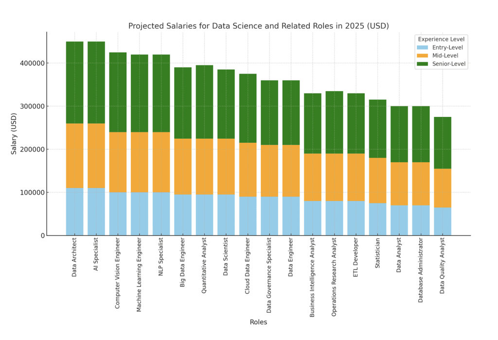

Data Science Salaries by Role

**Source:** https://www.kdnuggets.com/data-science-salaries-job-market-analysis-2024-2025

### Mapping Analysis

[output not shown]

## Visualization 2 - Multi-line Heat Map

**Image:**

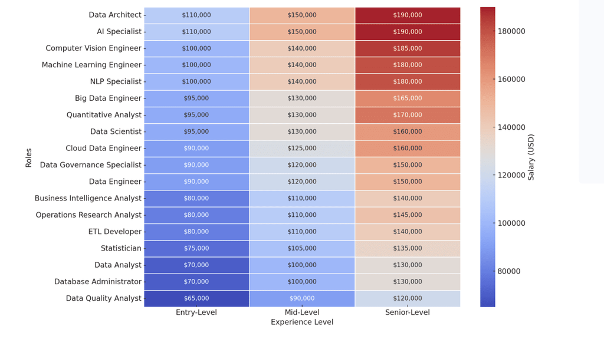

Salary Trends by Experience Level

**Source:** https://www.kdnuggets.com/data-science-salaries-job-market-analysis-2024-2025

**Chart type:** Multi-line Heat Map Chart (Levels Divided)

### Mapping Analysis

[output not shown]

### Effectiveness Note

The line trajectories illustrate strict dependency between color and value. With senior salaries growing from approximately $120K to $190K while entry-level positions rose more modestly from $65K to $110K. The downside is that we analyse the “Projected Salaries for Data Scientists and Related Roles in 2025” so it`s mosty a prediction, and a real data.

## Visualization 3 - Regular Heatmap

**Image:**

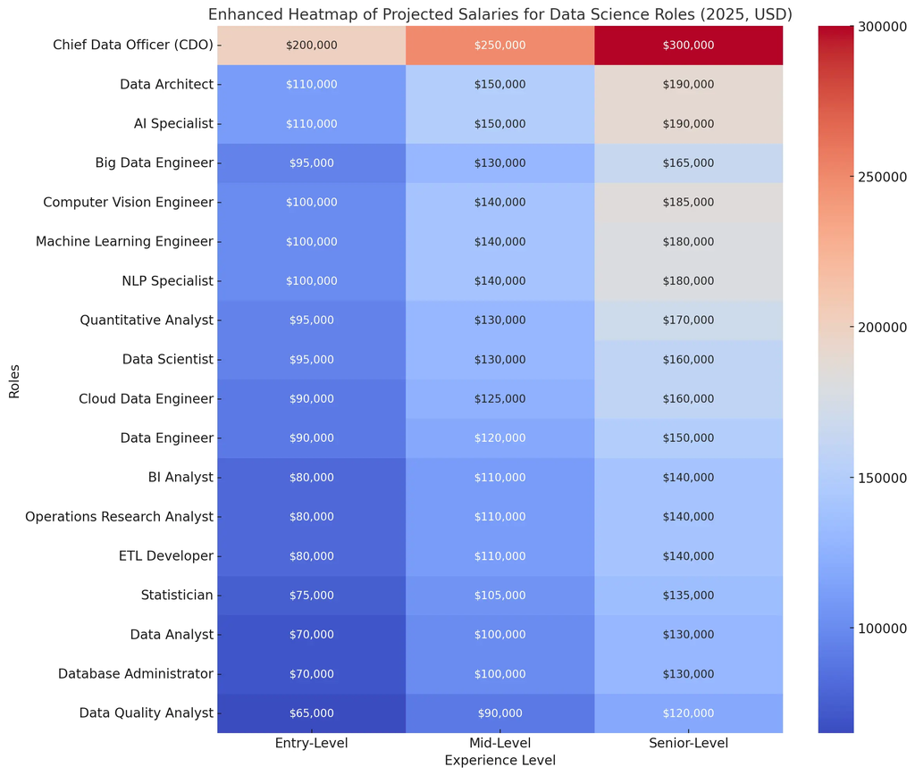

**Source:** https://www.refontelearning.com/salary-guide/data-science-salaries-unveiled

**Chart type:** Heatmap (Matrix visualization)

### Mapping Analysis

[output not shown]

## Visualization 4 - Vertical Bar Chart

**Image:**

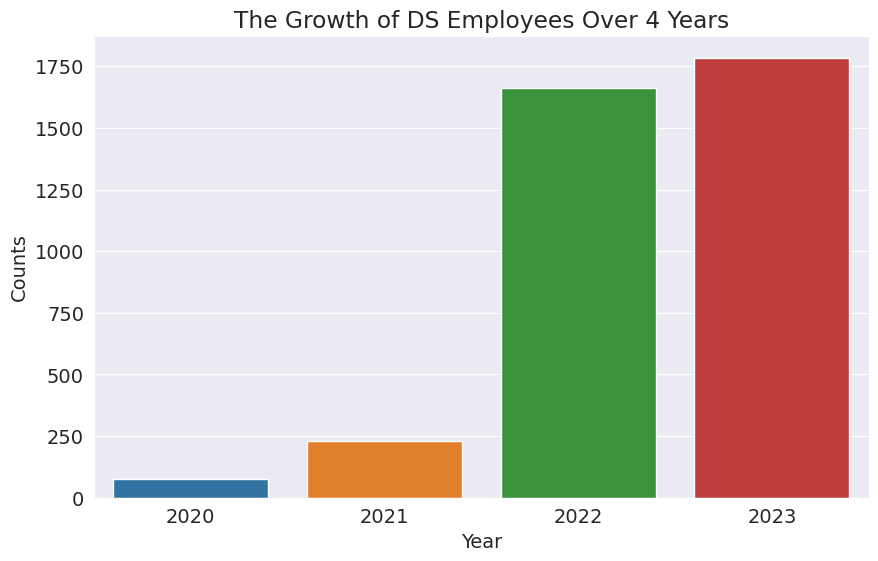

Distribution of Data Science Jobs

**Source:** https://www.kaggle.com/code/mohamedmagdy191/data-science-salaries-eda-visualization

**Chart type:** Vertical Bar Chart

### Mapping Analysis

| What’s being shown | Data type | Channel used |
| --- | --- | --- |
| Number of positions | Quantitative | Position (Y-axis), organized by value |
| Year (2020, 2021, 2022, 2023) | Temporal | Position (X-axis) |
| Color of columns | Categorical | Base Colors hue (Blue, Orange, Green, Red) |

### Effectiveness Note

Statistics show that each year there is more and more people that are interested in IT Sphere and in Data Science in particular. Even so, that graph is poorly describing numbers in terms of what jobs does it cover, or does data sum up each time or independently.

## Visualization 5 - Pie Chart

**Image:**

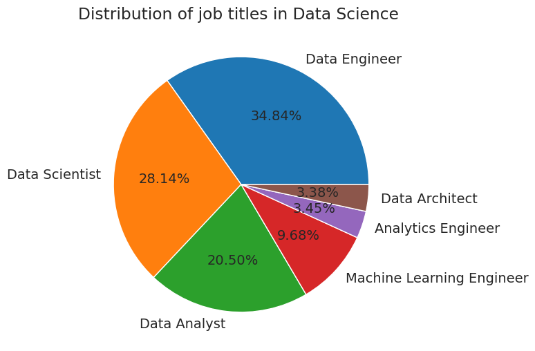

Distribution of Job Titles in Data Science

**Source:** https://www.kaggle.com/code/mohamedmagdy191/data-science-salaries-eda-visualization

**Chart type:** Pie Chart with percentage labels

### Mapping Analysis

| What’s being shown | Data type | Channel used |
| --- | --- | --- |
| Job titles (Data Engineer, Data Scientist,etc.) | Nominal | Pie slice/sector (angular position around 360° circle) |
| Percentage of total job postings | Quantitative | Slice angle and corresponding area (larger angle = higher percentage) |
| Exact percentage values | Quantitative | Text labels positioned at the approximate center/midpoint of each slice (e.g., “34.8%”, “28.1%”) |
| Job categories | Nominal | Color hue (distinct colors assigned to each job title, though colors appear randomly) |
| Visual hierarchy of job prevalence | Ordinal | Slices arranged in descending order non clockwise from largest to smallest |

### Effectiveness Note

The pie chart immediately communicates market concentration, showing that Data Engineer (34.8%) and Data Scientist (28.1%) together comprise nearly two-thirds (62.9%) of all data science job postings, establishing these as the dominant entry pathways into the field. The descending slice arrangement from largest to smallest creates clear visual hierarchy that guides the eye non naturally around the circle. However, the chart suffers from typical pie chart limitations: the smallest slices (those representing 2-4% of jobs) are difficult to distinguish and compare visually despite having percentage labels, as human perception struggles to accurately judge small angular differences.